# lab04_05

Notebook created by Jan Gądek

**Digital Signal Processing Lab**

**Frequency Analysis of Discrete-Time Signals**

**Notebook version:** 1.3

# Introduction

Discrete Fourier Transform is the basic tool in processing discrete signals. In this notebook, you will have to implement a few exercises that will expose you to frequency domain analysis of discrete signals.

## Reading list

Before working with the notebook, you might find it useful to become acquainted with the following materials:

- Section **8.1 Widmo Fouriera sygnałów dyskretnych** from “Cyfrowe przetwarzanie sygnałów : od teorii do zastosowań, WKŁ 2014” by T. P. Zieliński.
- Section **8.2 Przykłady dyskretnych transformat Fouriera sygnałow** from “Cyfrowe przetwarzanie sygnałów : od teorii do zastosowań, WKŁ 2014” by T. P. Zieliński.
- Section **8.3 Interpretacja dyskretnego przekształcenia Fouriera** from “Cyfrowe przetwarzanie sygnałów : od teorii do zastosowań, WKŁ 2014” by T. P. Zieliński.
- Section **8.4 Tor przetwarzania sygnałów podczas analizy częstotliwościowej** from “Cyfrowe przetwarzanie sygnałów : od teorii do zastosowań, WKŁ 2014” by T. P. Zieliński.
- Section **8.5 Dyskretne okna czasowe** from “Cyfrowe przetwarzanie sygnałów : od teorii do zastosowań, WKŁ 2014” by T. P. Zieliński.
- Section **8.6 Przykłady analizy częstotliwościowej z wykorzystaniem funkcji okien** from “Cyfrowe przetwarzanie sygnałów : od teorii do zastosowań, WKŁ 2014” by T. P. Zieliński.
- Section **9.1 Metoda bezpośrednia** from “Cyfrowe przetwarzanie sygnałów : od teorii do zastosowań, WKŁ 2014” by T. P. Zieliński.
- Section **9.5 Szybka transformacja Fouriera - algorytm radix-2** from “Cyfrowe przetwarzanie sygnałów : od teorii do zastosowań, WKŁ 2014” by T. P. Zieliński.

Students who aim for a good understanding of basic signal processing tools should also read the following sections:

- Section **8.7 Szybkie wyznaczanie funkcji autokorelacji i funkcji gęstości widmowej mocy** from “Cyfrowe przetwarzanie sygnałów : od teorii do zastosowań, WKŁ 2014” by T. P. Zieliński.
- Section **16.3 Krótkoczasowa transformacj Fouriera** from “Cyfrowe przetwarzanie sygnałów : od teorii do zastosowań, WKŁ 2014” by T. P. Zieliński.
- **Signal estimation from modified short-time Fourier transform,** by D. Griffin and Jae Lim., IEEE Trans. Acoust. Speech Signal Process., vol. 32, no. 2, pp. 236–243, Apr. 1984, [[IEEE Xplore](https://ieeexplore.ieee.org/document/1164317)]

## Notebook setup

```python
# Easy path management
from pathlib import Path

# Time utils
import time

# Simple HTTP requests
import requests

# NumPy package
import numpy as np

# Opening Waveform Audio File Format (*.wav)
from scipy.io import wavfile

# Some tools
from scipy.signal import firwin, lfilter, hann, freqz, cosine


# tqdm for displaying nice progress bar
from tqdm.auto import tqdm

# Matplotlib for plotting figures
from matplotlib import pyplot as plt
from matplotlib import colorbar
from mpl_toolkits.axes_grid1.axes_divider import make_axes_locatable
from mpl_toolkits.axes_grid1.colorbar import colorbar

# Audio class from ipython for displaying audio player in notebooks
from IPython.display import Audio
```

```python
def download(url, path):
    if not isinstance(path, Path):
        path = Path(path)
    if not path.is_file():
        r = requests.get(url)
        with open(path, "wb") as f:
            f.write(r.content)
```

# Discrete Fourier Transform (DFT)

Implement [DFT](https://en.wikipedia.org/wiki/Discrete_Fourier_transform) operation. You should implement it using two `for` loops (no vectorization here!).

**Discrete Fourier Transform (DFT)** $$\large \hat{\mathbf{x}}[k] = \sum_{n=0}^{N-1} \mathbf{x}[n] \exp\left( -j2\pi \frac{kn}{N} \right) $$

```python
def dft(x):
    N=len(x)
    X=np.zeros(N,dtype=complex)

    for k in range(0,N):
        for n in range(0,N):
            X[k]+=x[n]*np.exp(1j*(-2)*np.pi*(k*n*1/N))

    return X

    """
    This function should compute Discrete Fourier Transform
    using a naive implementation of the formula (direct implementation of the DFT formula).
    Don't hesitate to use for loops (hint: there should be two for loops).

    Parameters
    ----------
    x: numpy array of shape (N, )
        Vector containing samples of discrete signal in time domain.

    Returns
    -------
    X: numpy array of shape (N, )
        Vector containing samples of discrete signal in frequency domain.
    """
```

## Verify your implementation

To verify if the implementation computes DFT correctly, we use reference implementation of DFT `np.fft.fft` from NumPy and compare RMSE between the two outputs. If the RMSE is small enough, then it is probably correct.

```
RMSE: 3.402311070240441e-26
Your implementation succeeded
```

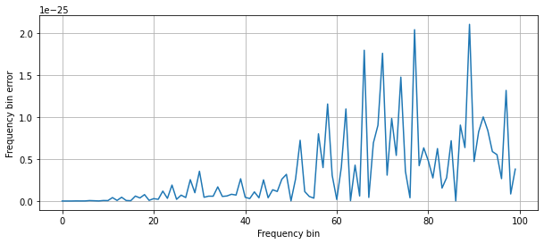

```python
fs = 1e2  # Sampling frequency
dt = 1/fs # Sampling interval
t_s = 0   # Start of sampling
t_e = 1   # End of sampling

# Generate timestamps of samples
t = np.arange(t_s, t_e, dt)

# Generate white noise signal as an test signal
x = np.random.randn(*t.shape)
#x=np.sin(t)
# Compute DFT using your implementation
X = dft(x)

# Compute DFT using reference DFT implementation from numpy
X_ref = np.fft.fft(x)

# Error between your implementation and reference implementation
X_err = np.abs(X - X_ref)**2

# Compute RMSE
X_RMSE = np.sqrt(np.mean(X_err)**2)

print('RMSE:', X_RMSE)
print('Your implementation succeeded' if X_RMSE < 1e-16 else 'That RMSE is a little bit too BIG!')

fig, ax = plt.subplots(nrows=1, ncols=1, figsize=(10, 4))
ax.plot(X_err)
ax.set_ylabel('Frequency bin error')
ax.set_xlabel('Frequency bin')
plt.grid()
plt.show()
```

# Amplitude and Phase of DFT

In this task, you have to finish the implementation of the function. The function plots the amplitude and phase characteristics of the DFT. The plot should show actual frequencies and amplitudes of the cosinusoidal components of the discrete signal.

Your goal is to implement the computation of three vectors inside function `plot_DFT`:

- Variable `freqs` is a vector that contains frequencies of each bin (we are interested in actual frequency in the Hertz unit, not in the index of the bin).
- Variable `A` is a vector that contains amplitudes for discrete frequency components.
- Variable `phase` is a vector that contains phases for discrete frequency components.

You should consider **all possible corner cases**.

For the following signal

$$ x(t) = 1 + 4\cos\left(14\pi t + \frac{\pi}{2}\right) + \cos \left(8\pi{}t - \frac{\pi}{2} \right), $$

sampled with sampling frequency $f_s = 16$ [Hz] within time interval $[0, 1)$, the plot should looks like this one below

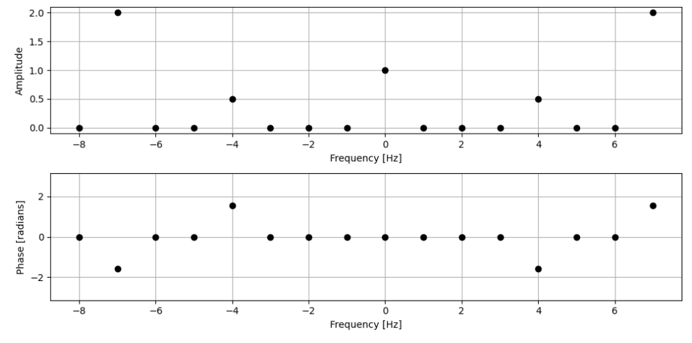

```python
def plot_DFT(X, fs, dB=False, plot=True):
    """
    This function plots amplitude and phase characteristics of the DFT

    Parameters
    ----------
    X: numpy array of shape (N, )
        Vector containing samples of the DFT
    fs: float
        Sampling frequency
    dB: boolean
        Show in dB

    Returns
    -------
    freqs: ndarray of shape (N, )
        Frequency vector
    A: ndarray of shape (N, )
        Ampliteude vector
    phase: ndarray of shape (N, )
        Phase vector

    """

    # Number of samples in signal
    N = X.size

    A=np.empty(N,)
    phase=np.empty(N,)

    if N%2==0:
        M=int(N/2)
        freqs = np.linspace(-fs/2,(fs/2)-1,num=N) # Compute it

        A_wr = np.abs(X)/N # Compute it
        A1=A_wr[M:]
        A2=A_wr[:M]
        for i in range(N):
            if i<N/2:
                A[i]=A1[i]
            else:
                A[i]=A2[i-M]

        phase_wr=np.angle(X)
        P1=phase_wr[M:]
        P2=phase_wr[:M]
        TF=np.isclose(A,0)

        for i in range(N):
            if i<N/2:
                phase[i]=P1[i]
            else:
                phase[i]=P2[i-M]

            if TF[i]==True:
                phase[i]=0


    if plot:
        # Plot signal
        fig, (ax_amp, ax_phase) = plt.subplots(nrows=2, ncols=1, figsize=(10, 5), dpi=100)

        if dB:
            A = 20*np.log10(A)
        ax_amp.plot(freqs, A, 'ko')
        if dB:
            ax_amp.set_ylabel('Amplitude [dB]')
        else:
            ax_amp.set_ylabel('Amplitude')
        ax_amp.set_xlabel('Frequency [Hz]')
        ax_amp.grid()

        ax_phase.plot(freqs, phase, 'ko')
        ax_phase.set_ylabel('Phase [radians]')
        ax_phase.set_xlabel('Frequency [Hz]')
        ax_phase.set_ylim([-np.pi*1.1, np.pi*1.1])
        ax_phase.grid()

        plt.tight_layout()
        plt.show()
    else:
        return freqs, A, phase_wr
```

```python
A=np.zeros(15)
X=np.arange(15)
N=X.size
M=int((N-1)/2)





print(A1.size,A2.size,'\n',A1,A2,M,'\n',A)
```

[output not shown]

## Verify your implementation

Examine your implementation with different lengths of signal (even/odd number of samples) and various sinusoidal components to verify the correctness of your implementation.

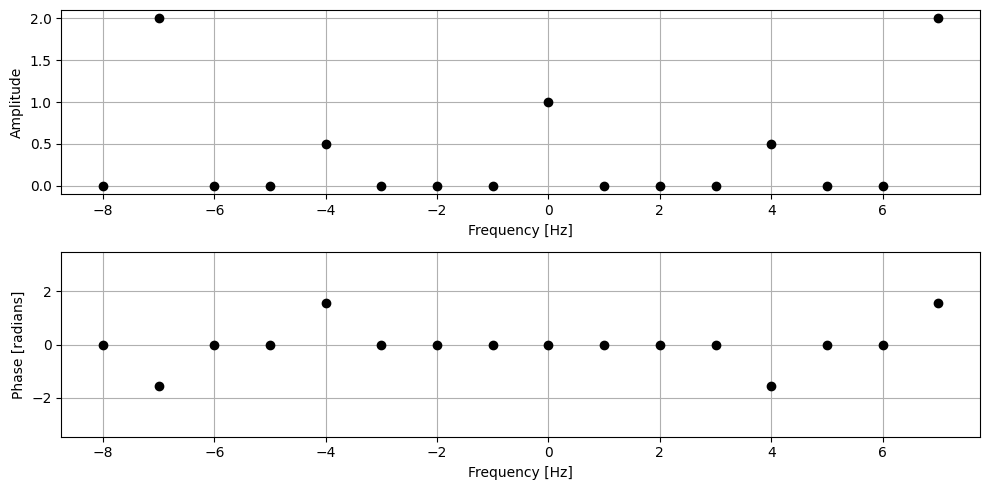

```python
fs = 16   # Sampling frequency
dt = 1/fs # Sampling interval
t_s = 0   # Start of sampling
t_s = 1   # End of sampling

# Generate timestamps of samples
t = np.arange(0, 1, dt)

# Generate reference signal
x = 1 + 4*np.cos(14*np.pi*t + np.pi/2) + np.cos(8*np.pi*t - np.pi/2)

# Compute DFT using your implementation
X = dft(x)

# Plot DFT spectrum
plot_DFT(X, fs=fs)
```

## Questions

**Question**: What is the phase of the complex number when module (amplitude) is equal to zero?

**Anwser**: [0/0] and we assume that phase is zero

# DFT as a linear map

DFT is a linear transformation and can be reformulated to the following form

$$\large \hat{\mathbf{x}} = \mathbf{E} \cdot \mathbf{x}, $$

where $\hat{\mathbf{x}} \in \mathbb{C}^{N}$, $\mathbf{E} \in \mathbb{C}^{N\times{}N}$, $\mathbf{x} \in \mathbb{R}^N$, and $N$ is the number of samples.

Implement DFT using matrix formulation. Figure out how to create matrix $\mathbf{E}$ based on the previously given formula of DFT. Your implementation must not use any loops and be fully vectorized.

```python
def mdft(x):

    N=x.size
    w_N=np.exp(1j*(-2)*np.pi*1/N)
    E=np.ones([N,N],dtype=complex)
    W=E*w_N

    A=np.arange(0,N)
    A=A.reshape(N,1)
    B=np.transpose(A)
    C=A*B

    E=W**C

    X=E@x
    return X


    """
    This function should compute Discrete Fourier Transform using matrix multiplication

    Parameters
    ----------
    x: numpy array of shape (N, )
        Vector containing samples of discrete signal in time domain.

    Returns
    -------
    X: numpy array of shape (N, )
        Vector containing samples of discrete signal in frequency domain.
    """
```

```python
a=np.arange(10)
a=a.reshape(10,1)
b=np.transpose(a)

c=a*b

print(b)
print(a)
print(c)
```

```
[[0 1 2 3 4 5 6 7 8 9]]
[[0]
 [1]
 [2]
 [3]
 [4]
 [5]
 [6]
 [7]
 [8]
 [9]]
[[ 0  0  0  0  0  0  0  0  0  0]
 [ 0  1  2  3  4  5  6  7  8  9]
 [ 0  2  4  6  8 10 12 14 16 18]
 [ 0  3  6  9 12 15 18 21 24 27]
 [ 0  4  8 12 16 20 24 28 32 36]
 [ 0  5 10 15 20 25 30 35 40 45]
 [ 0  6 12 18 24 30 36 42 48 54]
 [ 0  7 14 21 28 35 42 49 56 63]
 [ 0  8 16 24 32 40 48 56 64 72]
 [ 0  9 18 27 36 45 54 63 72 81]]
```

## Verify your implementation

```
RMSE: 1.713139709147651e-26
Your implementation succeeded
```

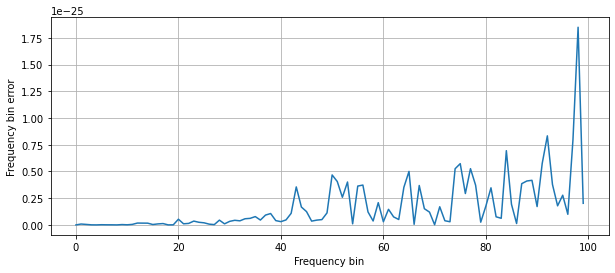

```python
fs = 1e2  # Sampling frequency
dt = 1/fs # Sampling interval
t_s = 0   # Start of sampling
t_e = 1   # End of sampling

# Generate timestamps of samples
t = np.arange(t_s, t_e, dt)

# Generate white noise signal as an test signal
x = np.random.randn(*t.shape)

# Compute DFT using your implementation
X = mdft(x)

# Compute DFT using reference DFT implementation from numpy
X_ref = np.fft.fft(x)

# Error between your implementation and reference implementation
X_err = np.abs(X - X_ref)**2

# Compute RMSE
X_RMSE = np.sqrt(np.mean(X_err)**2)

print('RMSE:', X_RMSE)
print('Your implementation succeeded' if X_RMSE < 1e-16 else 'That RMSE is a little bit too BIG!')

fig, ax = plt.subplots(nrows=1, ncols=1, figsize=(10, 4))
ax.plot(X_err)
ax.set_ylabel('Frequency bin error')
ax.set_xlabel('Frequency bin')
plt.grid()
plt.show()
```

## Questions

**Question**: For discrete signal of lenght $N$ is matrix $\mathbf{E}$ constant?

**Anwser**: for every length N there is constant E matix

# Fast Fourier Transform

Implement DFT using [radix-2](https://en.wikipedia.org/wiki/Cooley%E2%80%93Tukey_FFT_algorithm) Fast Fourier Transform (FFT).

```python
def fft_radix2(x):
    #X[k] = Even[k] + e^(...) * Odd[k]
    """
    This function should compute Discrete Fourier Transform using Fast Fourier Transform (radix-2) algorithm.

    Parameters
    ----------
    x: numpy array of shape (2**k, )
        Vector containing samples of discrete signal in time domain.
        `k` is integer constant.

    Returns
    -------
    X: numpy array of shape (2**k, )
        Vector containing samples of discrete signal in frequency domain.
        `k` is integer constant.
    """
    # Check if it is a vector
    assert x.ndim == 1, 'Input array should be 1-dimensional array, i.e x.shape == (N, )'

    # Number of samples in X
    N = x.size

    # Check if input array has proper shape
    assert np.log2(N).is_integer(), 'Number of samples should be 2**k'


    if N==1:
        return x
    else:
        E=fft_radix2(x[0:N:2])
        O=fft_radix2(x[1:N:2])

        M=int(N/2)
        #X_fir=X_sec=np.zeros(M,dtype=complex)

        w=np.exp((-2j)*np.pi*np.arange(N/2)/N)
        X_fir=E+w*O
        X_sec=E-w*O
        X=np.concatenate((X_fir, X_sec), axis=0)

    return X
```

```python
    #zero padding, niepotrzebny
    x=np.arange(9)
    n=0
    while True:
        if x.size<2**n:
            break
        else:
            n+=1

    x_new_size=2**n

    for i in range(x.size,x_new_size):
        x=np.append(x,0)

    print(x)



    y=np.arange(16)
    z=np.zeros(16,dtype=int)
    yp=y[0:y.size:2]
    ynp=y[1:y.size:2]
    M=int(x.size / 2)

    for i in range(8):
        w=i
        z[i]=yp[i]+ynp[i]
        z[8+i]=yp[i]-ynp[i]*w

    print(np.concatenate((yp, ynp)))
```

```
[0 1 2 3 4 5 6 7 8 0 0 0 0 0 0 0]
[ 0  2  4  6  8 10 12 14  1  3  5  7  9 11 13 15]
```

## Verify your implementation

```
RMSE: 1.9360155580235057e-28
Your implementation succeeded
```

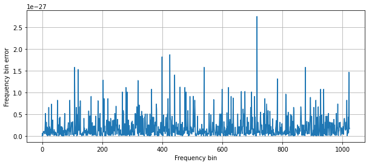

```python
fs = 2**10  # Sampling frequency
dt = 1/fs # Sampling interval
t_s = 0   # Start of sampling
t_e = 1   # End of sampling

# Generate timestamps of samples
t = np.arange(t_s, t_e, dt)

# Generate white noise signal as an test signal
x = np.random.randn(*t.shape)

# Compute DFT using your implementation
X = fft_radix2(x)

# Compute DFT using reference DFT implementation from numpy
X_ref = np.fft.fft(x)

# Error between your implementation and reference implementation
X_err = np.abs(X - X_ref)**2

# Compute RMSE
X_RMSE = np.sqrt(np.mean(X_err)**2)

print('RMSE:', X_RMSE)
print('Your implementation succeeded' if X_RMSE < 1e-16 else 'That RMSE is a little bit too BIG!')

fig, ax = plt.subplots(nrows=1, ncols=1, figsize=(10, 4))
ax.plot(X_err)
ax.set_ylabel('Frequency bin error')
ax.set_xlabel('Frequency bin')
plt.grid()
plt.show()
```

# Compare speed of DFT implementations (optional)

At this point, we have four different implementations of DFT. In this task, you have to write a simple benchmark for those functions to check how fast each implementation can compute DFT for the signal of length $N$. To estimate this value, you should execute $R = 10$ times each investigated function for a given signal of length $N$. As a result of the task, you should obtain four curves (for each function) on the figure where the x-axis corresponds to the number of samples and the y-axis corresponds to the mean time of execution.

To measure time in Python you can use following snippet:

```
t_start = time.time()

# Block of code. For example:
time.sleep(1) # Wait for a one second

t_end = time.time()

duration = t_end - t_start
print(duration)
```

Since `fft_radix2` works only for signals of length $2^k : k \in \mathbb{N}^+ $, you should choose only signals of those lengths to test. Below, there is a table that contains the proposed maximal number of samples $2^K$ for each function.

[output not shown]

Below is a started code that you can use.

```python
# Number of repetitions for each test point on characteristic
R = 10

# Dictionary containing DFT implementation with corresponding K value
DFT_IMPLEMENTATIONS_LIST = {
    'dft':        (dft, 7),
    'mdft':       (mdft, 11),
    'fft_radix2': (fft_radix2, 12),
    'fft':        (np.fft.fft, 15),
}

# This is a dict where you should store your results as a tuple (test_N, time)
# where test_N is a vector containing number of samples for which function was tested
# and time is a vector that containing mean execution time for signal of length N from test_N
results = {
    'dft':        None,
    'mdft':       None,
    'fft_radix2': None,
    'fft':        None,
}

# Put your code here
```

## Plot the results

[output not shown]

[figure not shown]

```python
fig, ax = plt.subplots(nrows=1, ncols=1, figsize=(10, 5), dpi=100)

for name, (test_N, r) in results.items():
    ax.plot(test_N, r, 'o-', label=name)

ax.set_xscale('log', base=2)
ax.set_yscale('log', base=10)

ax.set_ylabel('Mean time to compute DFT [s]')
ax.set_xlabel('Numer of samples')
ax.legend()
ax.grid()
plt.show()
```

## Question

**Question**: Consider $N$ samples of signal. Does the computation time of the DFT depends on the values of the singal?

**Anwser**: (Put your anwser here)

**Question**: What are theoretical computetional complexity of those implementations?

**Anwser**: (Put your anwser here)

**Question**: Explain why different implementation of DFT have particular curve on the characteristics obtained in figur from section 2.5.1.

**Anwser**: (Put your anwser here)

# Inverse Discrete Fourier Transform

Implement [inverse DFT](https://en.wikipedia.org/wiki/Discrete_Fourier_transform#Inverse_transform) operation. You can use any algorithm you know.

**Inverse Discrete Fourier Transform** $$\large {\mathbf{x}}[n] = \frac{1}{N} \sum_{n=0}^{N-1} \hat{\mathbf{x}}[k] \exp\left( j2\pi \frac{kn}{N} \right) $$

```python
def idft(X):
    N=len(X)
    x=np.zeros(N,dtype=complex)

    for n in range(0,N):
        for k in range(0,N):
            x[n]+=X[k]*np.exp(2j*np.pi*(k*n*1/N))

        x[n]=x[n]/N
    return x

    """
    This function should compute inverse Discrete Fourier Transform using naive implementation.

    Parameters
    ----------
    X: numpy array of shape (N, )
        Vector containing samples of discrete signal in frequency domain.

    Returns
    -------
    x: numpy array of shape (N, )
        Vector containing samples of discrete signal in time domain.
    """
    raise NotImplementedError
```

## Verify your implementation

```
RMSE: 1.6e-14
Your implementation succeeded
```

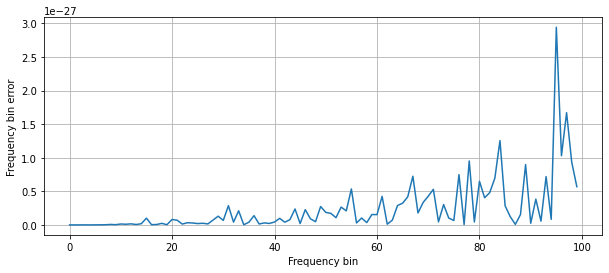

```python
fs = 1e2  # Sampling frequency
dt = 1/fs # Sampling interval
t_s = 0   # Start of sampling
t_e = 1   # End of sampling

# Generate timestamps of samples
t = np.arange(t_s, t_e, dt)

# Generate white noise signal
x = np.random.randn(*t.shape)

# Error between your implementation and reference implementation
X_err = np.abs(x - idft(np.fft.fft(x)))**2

# RMSE
X_RMSE = np.sqrt(np.mean(X_err))

print('RMSE:', np.round(X_RMSE, 15))
print('Your implementation succeeded' if X_RMSE < 1e-10 else 'That RMSE is a little bit too BIG!')

fig, ax = plt.subplots(nrows=1, ncols=1, figsize=(10, 4))
ax.plot(X_err)
ax.set_ylabel('Frequency bin error')
ax.set_xlabel('Frequency bin')
plt.grid()
plt.show()
```

## Questions

**Question**: Since DFT is a linear mapping it can be expressed as $\hat{\mathbf{x}} = \mathbf{E} \cdot \mathbf{x}$. Can we express inveres DFT as linear map $\mathbf{B}$ as well? If yes, is there any relation between $\mathbf{E}$ and $\mathbf{B}$?

# Numerical error of DFT (optional)

In this task, you should examine the numerical error introduced by iteratively applied DFT/iDFT operation on a sampled signal. In the $i^{\text{th}}$ iteration compute vector $\mathbf{x}_{i+1}$ as $$ \mathbf{x}_{i+1} = \mathrm{DFT}\Big(\mathrm{iDFT}\big(\mathbf{x}_{i} \big)\Big) \quad \text{ where } \mathbf{x}_{0} = \mathbf{x}_{\mathrm{ref}} $$ and store RMSE in `err` list for each iteration between vector $\mathbf{x}_{i+1}$ and $\mathbf{x}_{\mathrm{ref}}$.

Since in this task you have to iterate about 1000 times to get proper curve, you should use `np.fft.fft` and `np.fft.ifft` functions to perform `DFT` and `iDFT` quickly.

```python
# Put your code here
```

# Spectral Leakage

This task assumes that you are familiar with [spectral leakage](https://en.wikipedia.org/wiki/Spectral_leakage) and [window functions](https://en.wikipedia.org/wiki/Window_function). If not, feel free to read about them in Wikipedia/lectures/literature.

Consider a case when there are two frequency components in the signal. The first signal has an amplitude of 1. The second one has an amplitude of 0.0001. If the frequencies of those components hit frequency bins, then we will see two distinct peaks, as in the example below.

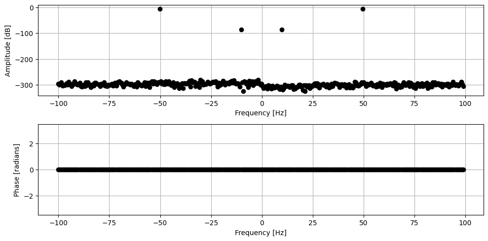

```python
fs = 2e2  # Sampling frequency
dt = 1/fs # Sampling interval
t_s = 0   # Start of sampling
t_e = 2   # End of sampling

# Generate timestamps of samples
t = np.arange(t_s, t_e, dt)

# Generate sampled signal
x = np.cos(2*np.pi*50*t) + 1e-4*np.cos(2*np.pi*10*t)

# Compute DFT
X = dft(x)

# Plot the spectrum
plot_DFT(X, fs=fs, dB=True)
```

But if the stronger peak has a slightly different frequency than frequency bins, spectral leakage makes a "mess" in the spectrum. Modify the below code in a way that the peak of the sinusoidal component with frequency 10 [Hz] will be visible in the spectrum. You must not change the parameters of the signal, i.e., the amplitudes and frequencies.

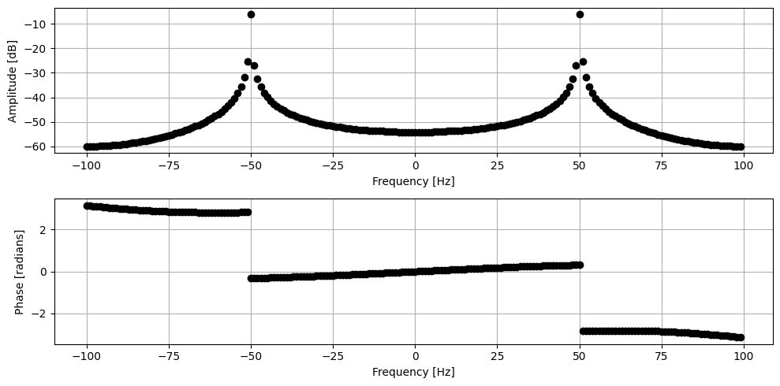

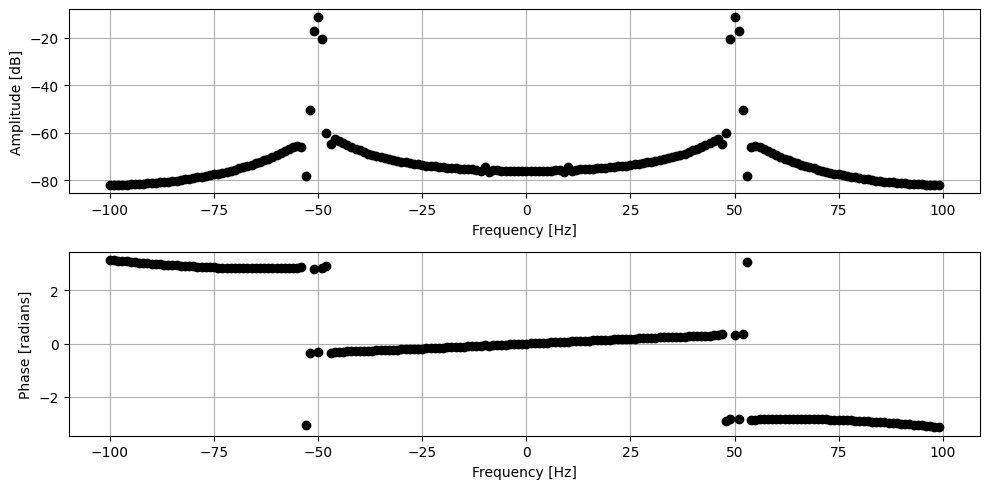

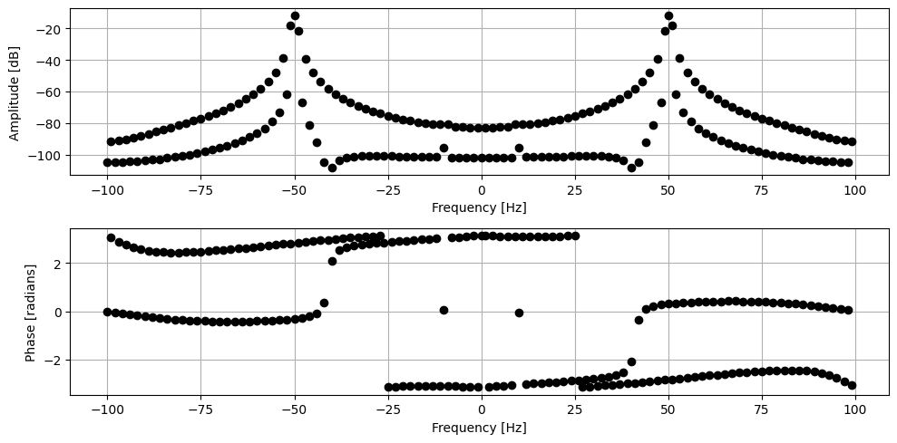

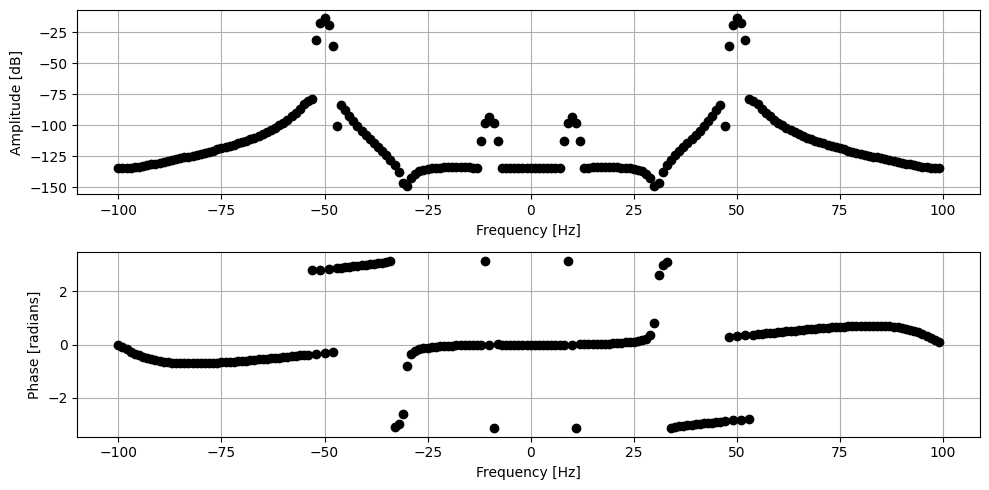

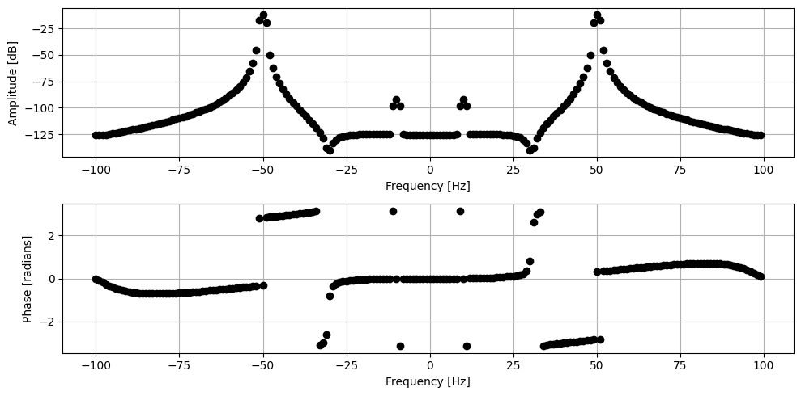

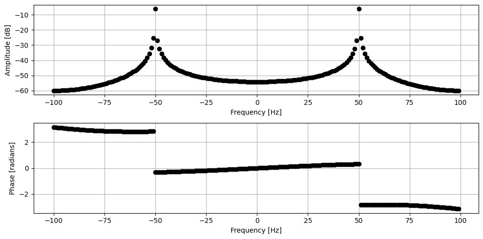

```python
fs = 2e2  # Sampling frequency
dt = 1/fs # Sampling interval
t_s = 0   # Start of sampling
t_s = 1   # End of sampling

# Generate timestamps of samples
t = np.arange(0, 1, dt)

# Generate signal
x = np.cos(2*np.pi*50.1*t) + 1e-4*np.cos(2*np.pi*10*t)

#####
# Apply some modifications to signal x
#####

#Hamming
N=x.size
win=np.hamming(N)
x_hamm=x*win


#Bartlett
N=x.size
win=np.bartlett(N)
x_bart=x*win


#Blackman
N=x.size
win=np.blackman(N)
x_bl=x*win


#Hanning
N=x.size
win=np.hanning(N)
x_hann=x*win

#Kaiser
N=x.size
win=np.kaiser(N,0)
x_kai=x*win

# Compute DFT
X = dft(x)
X_hamm = dft(x_hamm)
X_bart = dft(x_bart)
X_bl = dft(x_bl)
X_hann = dft(x_hann)
X_kai = dft(x_kai)

# Show DFT characteristics
plot_DFT(X, fs=fs, dB=True)
plot_DFT(X_hamm, fs=fs, dB=True)
plot_DFT(X_bart, fs=fs, dB=True)
plot_DFT(X_bl, fs=fs, dB=True)
plot_DFT(X_hann, fs=fs, dB=True)
plot_DFT(X_kai, fs=fs, dB=True)
```

## Questions

**Question**: Which window provides best frequency resolution (narrower main lobe)?

**Anwser**: (Put your anwser here)

**Question**: Which window provides worst dynamic range?

**Anwser**: (Put your anwser here)

# Discrete Time and Continous Frequency Fourier Transform (optional)

Implement Fourier Transform for discrete time samples with continous frequency.

**Discrete Time and Continous Frequency Fourier Transform** is given by $$\large \mathbf{X}(j\omega) = \sum_{n=-\infty}^{\infty} \mathbf{x}[n] \exp\left( -j \omega \cdot n \cdot \Delta t \right) $$

```python
def FT_dtcf(x, freqs, fs):

    N=x.size
    X=np.zeros(N,dtype=complex)
    dt=1/fs

    for w in range(fs):
        for n in range(N):
            X[w]+=x[n]*np.exp((-1j)*w*n*dt)

    """
    Parameters
    ----------
    x: numpy array of shape (N, )
        Vector containing samples of discrete signal in time domain.
    freqs: numpy array of shape (F, )
        Vector containing frequencies for which spectrum is computed.
    fs: float
        Sampling frequency

    Returns
    -------
    X: numpy array of shape (N, )
        Vector containing samples of discrete signal in frequency domain.
        fs: float
        Sampling frequency

    """
```

## Verify your implementation

Check if your implementations is correct using a few time-limted signal with known spectrum.

```python
fs = 40  # Sampling frequency
dt = 1/fs # Sampling interval
t_s = 0   # Start of sampling
t_s = 1   # End of sampling

# Generate timestamps of samples
t = np.arange(0, 1, dt)

# Generate signal
x = np.cos(2*np.pi*10.5*t)

# Compute spectrum
r = 40
freqs = np.arange(-r, r, 1e-1)

Xc = FT_dtcf(x, freqs, fs)

plt.figure(figsize=(16, 4))
plt.plot(freqs, np.abs(Xc), "g-", label="Continous Frequency")
plt.legend()
plt.grid()
plt.show()
```

[output not shown]

# Continous and discrete spectrum of discrete signals

Compare `DFT` with the output of Discrete Time and Continous Frequency Fourier Transform for a few signals. Investiage it for cases when spectral leakage is absent or present.

If you didn't implemented function `FT_dtcf`, interpolate the DFT with zero-padding at least ten times.

To plot characteristics on a single figure you can use following function to extract frequencies, amplitudes, and phases from DFT:

```
freqs, amps, phases = plot_DFT(X, fs, plot=False)
```

```python
# Code
```

## Questions

**Question**: What is relation between those two spectra?

**Anwser**: (Put your anwser here)

**Question**: Explain what causes spectral leakage.

**Anwser**: (Put your anwser here)

**Question**: Why zero-padding increases frequency resolution of the DFT?

**Anwser**: (Put your anwser here)

# Frequency domain low pass filtration (optional)

Implement low-pass filter in frequenc domain by zeroing bins with high frequencies.

```python
def LP_FFTFilter(x, f_lp, fs):
    """
    Parameters
    ----------
    x: numpy array of shape (N, )
        Vector containing samples of discrete signal in time domain.
    f_lp: float
        Low-pass cut-off frequency
    fs: float
        Sampling frequency

    Returns
    -------
    xf: numpy array of shape (N, )
        Filtered signal

    """
    raise NotImplementedError
```

## Verify your implementation

Check if your filtration in frequency domain works for spectra without leaks. Next try to investigate the performance of it for spectra with leaks.

```python
fs = 1e2  # Sampling frequency
dt = 1/fs # Sampling interval

# Generate timestamps of samples
t = np.arange(0, 10, dt)

# Generate white noise signal
x = np.cos(2*np.pi*8*t)

# Add high frequency signal
xh = x + 10*np.cos(2*np.pi*15*t)

# Filter signal
xf = LP_FFTFilter(xh, 10, fs)

# Compute characteristics of signal
Xh = np.fft.fft(xh)
fh, Ah, _ = plot_DFT(Xh, fs, plot=False)

# Compute characteristics of filtered signal
Xf = np.fft.fft(xf)
ff, Af, _ = plot_DFT(Xf, fs, plot=False)

# Plot
plt.figure(figsize=(16, 8))
plt.plot(fh, Ah, "ko", label="DFT")
plt.plot(ff, Af, "r.", label="DFT filtered")
plt.legend()
plt.grid()
plt.show()

plt.figure(figsize=(16, 8))
plt.title("Time domain")
plt.plot(t, x, 'k-', label="Original")
# plt.plot(t, xh, 'b-', label="Original + high")
plt.plot(t, xf, 'r-', label="Frequency Filtered")
plt.legend()
plt.show()
```

## Questions

**Question**: What are the flaws of filtration in discret frequency domain and why?

**Anwser**: (Put your anwser here)

## Audio example

```python
urls = {
    "speech0001.wav": "http://sp-class.agh.edu.pl/samples/speech0001.wav",
}

for filename, url in tqdm(urls.items()):
    download(url, filename)

fs, signal = wavfile.read("speech0001.wav")
print("Original audio")
display(Audio(signal, rate=fs))

print("Filtered audio")
signal_f = LP_FFTFilter(signal, 2000, fs)
display(Audio(signal_f, rate=fs))
```

## Questions

**Question**: You should hear weak ringing in filtered signal. Explain what happened.

**Anwser**: (Put your anwser here)

# Window parameters (optional)

Write a script or function that will compute numerically basic parameters of window.

```python
# Code
```

# Power Spectrum Density Estimation (supplementary)

Implement method `PSD_WELCH` that will estimate Power Spectrum Density (PSD) using [Welch's method](https://en.wikipedia.org/wiki/Welch%27s_method).

```python
def PSD_WELCH(x, window, D):
    raise NotImplementedError
```

## Verify your implementation

With simple signal

```python
fs = 1e2  # Sampling frequency
dt = 1/fs # Sampling interval
t_s = 0   # Start of sampling
t_e = 10   # End of sampling

# Generate timestamps of samples
t = np.arange(t_s, t_e, dt)

# Generate white noise signal
x = np.cos(2*np.pi*8.9*t) + np.cos(2*np.pi*34.1*t)

window = hann(512)

# Compute characteristics of filtered signal
PSD = PSD_WELCH(x, window, 128)

f, A, _ = plot_DFT(PSD, fs, plot=False)

# Plot
plt.figure(figsize=(16, 4))
plt.plot(f, A, "k.-", label="PSD")
plt.legend()
plt.grid()
plt.show()
```

Next, let's estimate PSD of some audio signal

```python
urls = {
    "speech0001.wav": "http://sp-class.agh.edu.pl/samples/speech0001.wav",
}

for filename, url in tqdm(urls.items()):
    download(url, filename)

fs, signal = wavfile.read("speech0001.wav")

window = hann(256)

# Compute PSD
PSD = PSD_WELCH(signal, window, 64)
f_psd, A_psd, _ = plot_DFT(PSD, fs, plot=False)

# Compute DFT of a signal
i_start = 16000
X = np.fft.fft(signal[i_start:i_start+window.size])
f_dft, A_dft, _ = plot_DFT(X, fs, plot=False)

# Plot
plt.figure(figsize=(16, 4))
plt.semilogy(f_psd, A_psd, "k.-", label="PSD")
plt.semilogy(f_dft, A_dft**2, "r.-", label="DFT")
plt.legend()
plt.grid()
plt.show()
```

## Questions

**Question**: Why even bother with PSD? Why DFT is not enought?

**Anwser**: (Put your anwser here)

# FM demodulation (supplementary)

In this task, you will demodulate FM signal from a radio station. The IQ data you will process were sampled around 89 [MHz] with sampling frequency 3 [MHz]. Let's download IQ samples.

```python
urls = {
    "FM.wav": "http://sp-class.agh.edu.pl/samples/FM.wav",
}

for filename, url in tqdm(urls.items()):
    download(url, filename)
```

and load them into the memory. Notice that variable `FM` is quite a bit one. For the purpose of prototyping you should stick to just one second of signal, i.e., 3000000 samples. When your script for FM demodulation will be ready, you can take more samples.

```python
# Load IQ samples
fs, FM = wavfile.read("FM.wav",)
sample_len = 3_000_000
FM = FM[:sample_len, 0] + 1j*FM[:sample_len, 1]
```

To identify the band of each radio station, you need to see the signal spectrum. Estimate PSD using Welchs' method and look for bands where the power of the signal is above the noise floor. Next, shift the frequency of the signal (using DFT properties), so that the selected band which contains the radio station signal is centered around frequency 0. When you successfully shift the desired signal into the baseband, you need to filter out everything else. Since the DFT filtration you learned about is not a good idea to use here, you should use a more proper filtration method. For now, you should use methods from `scipy.signal`, like `firwin` to design an FIR filter and `lfilter` to perform filtration. Below is a snippet of how to design an FIR filter and perform filtration with it, but take a look at the documentation before running it. In the next laboratories, you will implement those functions on your own.

```
h_lp = firwin(order, f_lp., fs=fs, window="hanning")
filtered = lfilter(h_lp, 1., signal)
```

You should use `order` around 100. Figure out on your own the low-pass cut-off frequency on your own.

After the filtration, the signal is ready to be demodulated. If you don't know how to do it, search for the information. The last step is to downsample the signal to a lower frequency. Now it's 3 [MHz], definitely too high for audio, so just take every 100-th sample from the signal, to downsample it to 30 [kHz]. The signal should be ready to listen. If you did everything correctly, you should hear a noisy audio signal.

```python
# Code
```

# Short-Time Frequency Analysis (supplementary)

We are often interested in what frequency content is present in a signal, as it can provide insight into what type of signals are present. Such an analysis could help us distinguish unique sources and even suppress undesirable ones with the appropriate processing!

For frequency analysis, we rely on the Discrete Fourier Transform (DFT). The DFT of a signal will yield a frequency spectrum, allowing us to identify key frequency components in a signal. Below we take the DFT of a signal containing speech.

```python
fs, signal = wavfile.read('speech0001.wav')

w, Y = freqz(signal, worN=2**12)

plt.figure(figsize=(20,7))
plt.loglog(w*fs/np.pi/2+1, np.abs(Y))
plt.title('Spectrum of linear chirp');
plt.ylabel('|F_{lin}| [dB]');
plt.xlabel('Frequency [Hz]');
plt.xlim([min(w*fs/np.pi/2+1), max(w*fs/np.pi/2)]);
plt.grid()
plt.show()
```

In the above example, we computed the spectrum over the entire audio signal, namely $57'040$ samples. This corresponds to $3.57$ seconds for the sampling rate of $16$ kHz. If performing real-time analysis, waiting for this many samples to perform frequency analysis (and further processing) would incur way too much latency!

For real-time frequency analysis (and processing), we will therefore have to work with much fewer samples, on the order of $20-40$ milliseconds so that the delay is not noticeable for human hearing. However, using fewer samples / a shorter FFT results in a "poorer" frequency resolution. In other words, we have a tradeoff between temporal and frequency resolution. You can read more about this [here](https://electronics.stackexchange.com/questions/12407/what-is-the-relation-between-fft-length-and-frequency-resolution/12412#12412).

We will call a small chunk of $20-40$ milliseconds a frame. By performing the frequency analysis of consecutive frames, we can form a spectrogram, visualizing how frequency content varies over time.

In this sectio, you task is following:

- Familiarize yourself with literatura. Expecially Section 16.3 "Krótkoczasowa transformacj Fouriera" from CPS T. Zieliński and "Signal estimation from modified short-time Fourier transform" by D. Griffin and Jae Lim.
- Implement function that computes STFT of given signal, for given analysis window and overlap.
- Implement a iSTFT function that will synthesis time-domain signal from STFT representation.
- Implement algorithm for phase recovery from spectogram (estimate phases from amplitudes).

## Analysis

```python
def STFT(x, a_win, L, N=None):
    """
    This function computes Short-Time Fourier Transfor of the signal

    Parameters
    ----------
    x: ndarray of shape (S, )
        vector that contains signal
    a_win: ndarray of shape (W, )
        Analysis window
    L: int
        Overlap between consecutive frames
    N: int
        Number of discrete frequencies in output STFT

    Returns
    -------
    X: ndarray of shape (K, N) where K is the number of frames.
        Complex matrix containing Short-Time Fourier Transfor of signals x
    """

    raise NotImplementedError
```

## Spectogram

[Spektogram](https://en.wikipedia.org/wiki/Spectrogram) $\mathrm{S}(t,f)$ is given as:

\begin{equation} \mathrm{S}_x(t, f) = \left| STFT_x(t, f) \right|^2 \end{equation}

It shows the energy of the particular frequency at given time.

```python
def spectogram(Yst, fs, duration=1, ax=None, figsize=(20, 5), minmax=None, eps=1e-16):
    """

    """
    if ax is None:
        fig, ax_local = plt.subplots(1, 1, figsize=figsize)
    else:
        ax_local = ax

    N = Yst.shape[-1]

    Y_spec = np.abs(Yst[:, :N//2])**2
    extent = [0, duration, 0, fs/2]

    if minmax is None:
        norm_colors=colors.LogNorm(vmin=Y_spec.min()+eps, vmax=Y_spec.max())
    else:
        norm_colors=colors.LogNorm(vmin=minmax[0]+eps, vmax=minmax[1])

    im = ax_local.imshow(Y_spec.T+eps, aspect='auto', origin='lower', extent=extent, norm=norm_colors, interpolation="none")
    ax_divider = make_axes_locatable(ax_local)
    cax = ax_divider.append_axes("top", size="7%", pad="2%")
    cb = colorbar(im, cax=cax, orientation="horizontal")
    cax.xaxis.set_ticks_position("top")
    cax.yaxis.set_ticks_position("right")

    ax_local.set_xlabel('Time')
    ax_local.set_ylabel('Frequency')
    if ax is None:
        plt.show()
```

### Show spectogram

```python
if False:
    fs = 1e3  # Sampling frequency
    dt = 1/fs # Time step
    t = np.arange(0, 1, dt) # Time vector

    # Compute different signal
    # y = ones(size(t)); # Constant signal
    # y = sin(2*pi*250*t); # Single sin
    y = np.sin(2*np.pi*50*t) + 10*np.sin(2*np.pi*300*t); # Two sins

    T, f0, f1, phi0 = 1, 100, 400, 0 # Chirp parameters
    y = np.sin(phi0 + 2*np.pi*(f0+(f1 - f0)/T/2*t)*t) # Chirp signal
else:
    fs, signal = wavfile.read('speech0001.wav')
    t = np.arange(0, len(signal)/fs, 1/fs)
    y = signal

# STFT parameters
win_time = 40e-3    # Lenght of the window [s]
win_overlap = 25e-3  # Overlap between frames [s]
win_length = int(win_time*fs) # Lenght of the window [samples]
L = np.ceil(win_overlap*fs); # Overlap between frames [samples]

#  analysys windows (uncomment one)
a_win = np.ones((win_length))  # Rectangular window
a_win = hann(win_length)  # Hamming window
# a_win = blackman(win_length) # Blackman window

# Number of samples per fft used to compute DFT (must be longer then win_length)
N = win_length*2;

# Compute STFT
Yst = STFT(y, a_win, L, N)

# Plot STFT

fig, (axT, axS) = plt.subplots(nrows=2, ncols=1, figsize=(20, 20))

axT.plot(t, y)
axT.set_title('Signal')
axT.set_ylabel('f(t)')
axT.set_xlabel('Time [s]')
axT.set_xlim([0, t.max()])
spectogram(Yst, fs, duration=t.max(), ax=axS)

plt.show()
```

## Synthesis

```python
def iSTFT(X, s_win, L):
    """
    This function computes inverse of Short-Time Fourier Transfor

    Parameters
    ----------
    X: ndarray of shape (K, N)
        vector that contains signal
    s_win: ndarray of shape (W, )
        Synthesis window
    L: int
        Overlap between consecutive frames

    Returns
    -------
    x: ndarray of shape (S,) where K is the number of samples.
        Time domain signal
    """
    raise NotImplementedError
```

### Verify iSTFT

Check if it works for `cosine` window with overlap 50%. Next, check the result when overlap is different or windows is different.

```python
if False:
    fs = 1e3  # Sampling frequency
    dt = 1/fs # Time step
    t = np.arange(0, 1, dt) # Time vector

    # Compute different signal
    # y = ones(size(t)); # Constant signal
    # y = sin(2*pi*250*t); # Single sin
    y = np.sin(2*np.pi*50*t) + 10*np.sin(2*np.pi*300*t); # Two sins

    T, f0, f1, phi0 = 1, 100, 400, 0 # Chirp parameters
    y = np.sin(phi0 + 2*np.pi*(f0+(f1 - f0)/T/2*t)*t) # Chirp signal
else:
    fs, signal = wavfile.read('speech0001.wav')
    t = np.arange(0, len(signal)/fs, 1/fs)
    y = signal / np.abs(signal).max()


# Parmaeters of STFT
# STFT parameters
win_time = 40e-3    # Lenght of the window [s]
win_overlap = 20e-3  # Overlap between frames [s]
win_length = int(win_time*fs) # Lenght of the window [samples]
L = int(np.ceil(win_overlap*fs)) # Overlap between frames [samples]

#  analysys windows (uncomment one)
win = cosine((win_length))  # Cosine window
# win = np.ones((win_length))  # Rectangular window
# win = hann(win_length)  # Hamming window
# a_win = blackman(win_length) # Blackman window

# Number of samples per fft used to compute DFT (must be longer then win_length)
N = win_length*2;


# Compute STFT of y
Yst = STFT(y, win, L, N);

# Compute iSTFT of Yst
y_r = iSTFT(Yst, win, L)

# Compute STFT of y_r
Yst_r = STFT(y_r, win, L, N);

# Compute difference
mLen = np.minimum(y.size, y_r.size)
y_diff = y[:mLen] - y_r[:mLen]

# Compute STFT of difference
Yst_diff = STFT(y_diff, win, L, N);
```

```python
fig, ((ax_o, ax_o_st), (ax_diff, ax_diff_st), (ax_r, ax_r_st)) = plt.subplots(nrows=3, ncols=2, figsize=(15, 10))

ax_o.set_title('Waveform of the signal')
ax_o.plot(y)
ax_o.grid()

ax_diff.set_title('Difference between original of waveform and reconstuction')
ax_diff.semilogy(y_diff)
ax_diff.grid()

ax_r.set_title('Reconstructed waveform of the signal')
ax_r.plot(y_r)
ax_r.grid()

minimax = [1e-6, 10]

spectogram(Yst, fs=fs, duration=t_1, ax=ax_o_st, minmax=minimax)

spectogram(Yst_diff, fs=fs, duration=t_1, ax=ax_diff_st, minmax=minimax)

spectogram(Yst_r, fs=fs, duration=t_1, ax=ax_r_st, minmax=minimax)

plt.show()
```

## Optimal Synthesis Window

Implement function that computes optimal synthesis window and check if the STFT analysis and synthesis works for different windows and overlaps than cosine window with 50% overlap.

```python
def optimal_synth_window(window, L):
    """
    This function computes optimal synthesis window

    Parameters
    ----------
    window: ndarray of shape (W,)
        Analysis window
    L: int
        Overlap between consecutive frames

    Returns
    -------
    s_window: ndarray of shape (W,)
        Synthesis window
    """
    raise NotImplementedError
```

## Phase recovery of the signal from spectogram

Implement function which will recover phases from spectogram using Griffin-Lim method. Write a script that presents results.

```python
# Code
```